# GAM

Master Data Science: Verónica Gómez, Carlos Grande, Pablo Olmos

2020

## Planteamiento del Problema

Intetaremos a través de las nuevas técnicas conocidase en el trimestre para intentar predecir la variable dependiente Precio de Compra. Vamos a aboradar el proceso de dos maneras: 1.-Por un lado tenemos la Variable Precio de forma continúa, ésta será nuestra variable objetivo dentro de un modelo GAM 2.-y por otro depúes de haber terminado el análisis clúster de las poblaciones de viviendas dividido en Top, Med y Low intentaremos predecir la pertenencia a cada unos de los grupos a través de un GAM, link function multiclass logistic.

Por último destacar como punto clave que la literatura recomienda usar modelos GAM en el caso de que exista un problema de Geolocalización en los datos con coordenadar X,Y como es nuestro caso.

# Secuencia del Trabajo Modelo GAM1:

## 1.-Lectura del Fichero

## 2.-Ridge y Lasso selección de variables

## 3.-GAM model

## 4.-Validación e interpretación de los datos.

## 5.-GAM model Link Logistic. Parte2

# 1. Modelo GAM. Variable Dependiente Precio Continua.

https://pdfs.semanticscholar.org/dea4/adaaf06e6fc99179a2620b7a031188c6e532.pdf

Como pudimos comprobar en el trimestre anterior los tradicionales modelos lineales a menudo fallan cuando planteamos problemas no lineales que suele ser lo habitual en la vida real. Con esta técnica queremos identificar los efectos no lineales de nuestros dantos dentro de un modelo predictivo de regresión.

Los GAM son un buen punto intermedio entre los modelos lineales (lm) y los modelos no paramétricos (p.e. Random Forest)

Planteamos el uso del modelo GAM dentro de la Regression Lineal ya que hemos comprobado que nuestro modelo contiene efectos no lineales.

1.- Las relaciones entre los predictores individuales y la variable dependiente siguen una función Smooth (suavizada), que puede ser lienal o no. 2.- Podemos estimar estas relaciones simultáneamente y predecir g(e(Y)) simplemente sumándolas 3.- Matemáticamente, GAM como

```
      g(E(Y))= a + s1(x1) + ....+ sp(zp)

    donde Y es la variable dependiente y g(Y) link function que vincula Y con x1,x2...xp

s(x1), s(x2)...s(xp)  son las smooth non parametrics fuctions (small set of parameters)
Notar quepodemos usar en GLM
for example Logit Link g(E(y))= log ( p(Y=1)/P(Y=0))
```

Las razones por las que vamos a emplear GAM son:

1.-Interpretabilidad 2.-Fexibiliad y automatización 3.-Regularización

## 1Interpretabilidad

La interepretación de un impacto marginal de una variable NO depende del valor de otras variables en el modelo. Por tanto con un simple vistazo al output del modelo podemos hacer una interepretación de la variable en el modelo. La posibilidad de controlar el ‘smoothness’ de las funciones predictoras.

## 2Flexibility and Automation

GAM es capaz de capturar patrones no lineales. Estos patrones van desde “hockey sticks” que se producen cuando se observa un “sharp” en la respuesta a varios tipos de “mountain shaped”. En los fitting de modelos parametrics de regression estos efectos no lienales son habitualmente recogidos a través de polinomios el cual genera un modelo poco eficiente. Con el modelo GAM no tenemos estos problemas, las funciones de predcicción se derivan automaticamente durante la estimación del modelo. No necesitamos saber por adelantado qué tipo de funciones necesitaremos. Ahorro de tiempo y nos encontará patrones perdidos en los modelos paramétricos.

## 3regularización

Nos permite controlar el “smoothness” de la funciones predictoras para eviar el Overfiting. Controlando “the wiggliness” evitar el sesgo. Las funciones de penalización del GAM tienen conexiones con la regresión Bayessiana y la L2.

Smoothers

```
Snoothers son las clave del GAM, tenemos tres clases de Smoothers:

1.-Local Regression (loess)
2.-Smoothing Splines
3.-Regression Splines ( B-splines, P-splines, thin plate splines)
```

RS, computacionalmente barato, es que emplearemos más habitualmente. La principal ventaja es que puede ser expresada como una combinación lienal de un conjunto finito de funciones básicas las cuales No dependen de la variable Y. S(x) => Bp,1(x)…Bp,k(x) funciones básicas donde B es la matriz dónde se albergan y B=[B1:B2:…..:Bp] son los coeficinetes. El número de funciones básicas depende de el número de “inner knots”(m) (TODO), p numero de parámetros.

Número de funciones básicas K = p + 1 + m

# Lectura Datos

```r
setwd("C:/Users/Pablo/Desktop/Machine_Learning_I/Z_PRACTICA_MACHINE_LEARNING/machineLearning1Process")
df_cluster <- read.csv ("cluster.csv")

#descriptivo en cada Clúster
set.seed(737)
df_cluster %>%
        group_by(hclust) %>%
        summarise(num_casas=n(), precio_medio= mean(price), room=mean(bedrooms),baths=mean(bathrooms) ,
                  tamanyo=mean(sqft_living), anyo=floor(mean(yr_built)) ,grade=mean(grade), condicion=mean(condition),        visitas=mean(view))
```

```
## # A tibble: 9 x 10
##   hclust num_casas precio_medio  room baths tamanyo  anyo grade condicion
##    <int>     <int>        <dbl> <dbl> <dbl>   <dbl> <dbl> <dbl>     <dbl>
## 1      1      4630      483131.  3.01  1.52   1553.  1936  6.90      3.66
## 2      2      1032      869438.  3.44  2.34   2420.  1942  7.86      3.27
## 3      3      2859      581478.  3.49  2.02   2042.  1970  7.57      3.61
## 4      4      1614      619128.  3.63  2.61   2615.  1998  8.44      3.12
## 5      5      2230      381906.  3.64  2.52   2339.  1997  7.89      3.14
## 6      6      1790      540015.  3.50  2.00   2083.  1957  7.48      3.40
## 7      7      1962      568348.  3.14  2.55   1932.  2003  8.09      3.04
## 8      8      2370      864266.  3.81  2.83   3107.  1994  9.09      3.19
## 9      9      3110      286567.  3.19  1.72   1633.  1968  6.97      3.66
## # ... with 1 more variable: visitas <dbl>
```

```r
df_cluster$hclust=as.numeric(df_cluster$hclust)
df_cluster$Cluster_final[df_cluster$hclust==2 | df_cluster$hclust==8] <- "top"
df_cluster$Cluster_final[df_cluster$hclust==1 | df_cluster$hclust==5 | df_cluster$hclust==9] <- "low"
df_cluster$Cluster_final[df_cluster$hclust==3 | df_cluster$hclust==4 | df_cluster$hclust==6 | df_cluster$hclust==7  ] <- "med"



df_cluster %>%
        group_by(Cluster_final) %>%
        summarise(num_casas=n(), precio_medio= mean(price), room=mean(bedrooms),baths=mean(bathrooms) ,
                  tamanyo=mean(sqft_living), anyo=floor(mean(yr_built)) ,grade=mean(grade),condicion=mean(condition),visitas=mean(view))
```

```
## # A tibble: 3 x 10
##   Cluster_final num_casas precio_medio  room baths tamanyo  anyo grade
##   <fct>             <int>        <dbl> <dbl> <dbl>   <dbl> <dbl> <dbl>
## 1 low                9970      399175.  3.21  1.81   1754.  1960  7.14
## 2 med                8225      576711.  3.44  2.26   2137.  1980  7.84
## 3 top                3402      865835.  3.70  2.68   2899.  1978  8.72
## # ... with 2 more variables: condicion <dbl>, visitas <dbl>
```

```r
set.seed(737)
inTraining <- createDataPartition(df_cluster$id, p = .7, list = FALSE)
train    <- df_cluster[inTraining,]
control  <- df_cluster[-inTraining,]
```

# Ridge regression

Intenta minimizar el RSS, ridge regression incorpora un término llamado shrinkage penalty que fuerza a que los coeficientes de los predictores tiendan a cero controlada por el parámetro λ. Cuando λ=0 la penalización es nula y los resultados son equivalentes a los obtenidos por mínimos cuadrados, cuando λ=∞ todos los coeficientes son cero. La principal ventaja es la reducción de Varianza. Si todos los predictores incluidos tienen coeficientes diferentes a cero (todos contribuyen al modelo) y aproximadamente de la misma magnitud, ridge regression tiende a funcionar mejor.

Para realizar ridge regression se va a emplear la función glmnet() del paquete glmnet.

```r
#matriz con las valores de los predictores para cada observación y un vector y=target variable respuesta
x <- model.matrix(price~  (bedrooms+ bathrooms+floors+sqft_living+grade+condition+view+waterfront+                           sqft_lot+sqft_above+sqft_basement+yr_built+yr_renovated+yr_renovated+
                            sqft_living15+sqft_lot15), data = train)[, -1]
head(x)
```

```
##   bedrooms bathrooms floors sqft_living grade condition view waterfront
## 1        3      1.00      1        1180     7         3    0          0
## 2        3      2.25      2        2570     7         3    0          0
## 3        2      1.00      1         770     6         3    0          0
## 4        4      3.00      1        1960     7         5    0          0
## 5        3      2.00      1        1680     8         3    0          0
## 6        4      4.50      1        5420    11         3    0          0
##   sqft_lot sqft_above sqft_basement yr_built yr_renovated sqft_living15
## 1     5650       1180             0     1955            0          1340
## 2     7242       2170           400     1951         1991          1690
## 3    10000        770             0     1933            0          2720
## 4     5000       1050           910     1965            0          1360
## 5     8080       1680             0     1987            0          1800
## 6   101930       3890          1530     2001            0          4760
##   sqft_lot15
## 1       5650
## 2       7639
## 3       8062
## 4       5000
## 5       7503
## 6     101930
```

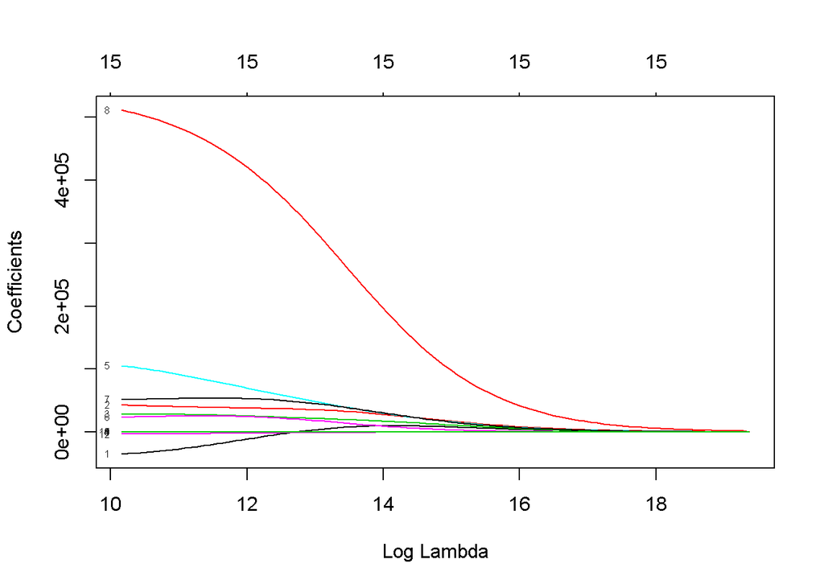

```r
y <- train$price


# Para obtener un ajuste mediante ridge regression se indica argumento alpha=0.
modelos_ridge <- glmnet(x = x, y = y, alpha = 0)
plot(modelos_ridge, xvar = "lambda", label = TRUE)
```

Al aumentar el tamaño de los Lambda dismunuyen los coeficientes. Con el fin de identificar el valor de λ que da lugar al mejor modelo, se puede recurrir a Cross-Validation. La función cv.glmnet() calcula el cv-test-error, utilizando por defecto k=10.

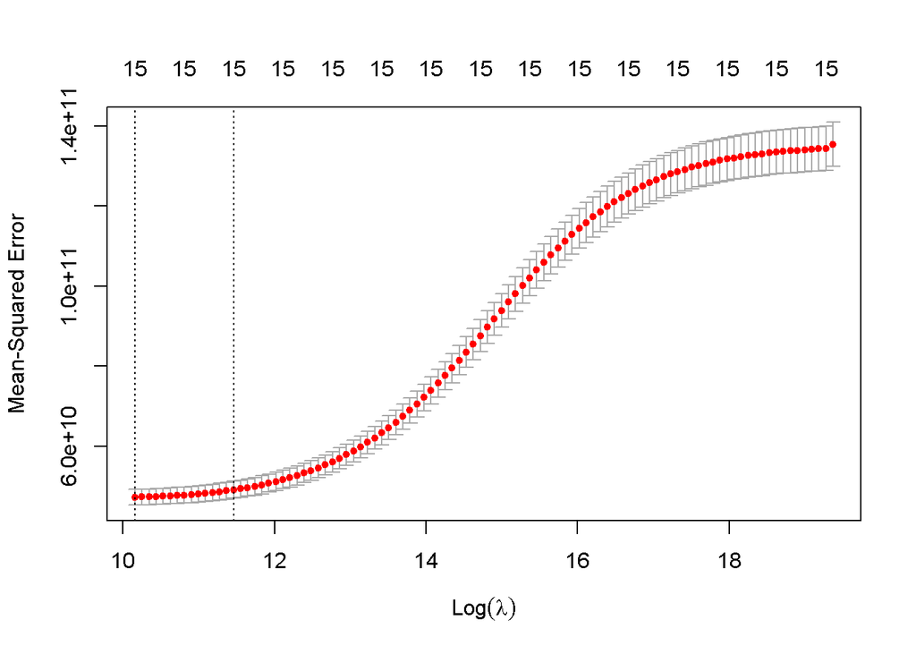

```r
set.seed(737)
cv_error_ridge <- cv.glmnet(x = x, y = y, alpha = 0, nfolds = 15,
                            type.measure = "mse")
plot(cv_error_ridge)
```

Podemos observar cómo varía el error cuadrático medio, en función del valor de regularización. Gráficamente se comprueba que el error no aumenta hasta que las variables con coeficiente mayor que cero es menor que -2, pero el menor error cuadrático medio se da para 15 variables regresoras y se mantiene constante. Es una de las grandes diferencias con Lasso.

```r
# Valor lambda con el que se consigue el mínimo test-error
cv_error_ridge$lambda.min
```

```
## [1] 25787.66
```

```r
# Valor lambda óptimo: mayor valor de lambda con el que el test-error no se
# aleja más de 1 sd del mínimo test-error posible.
cv_error_ridge$lambda.1se
```

```
## [1] 94856.79
```

```r
# Se muestra el valor de los coeficientes para el valor de lambda óptimo

modelo_final_ridge <- glmnet(x = x, y = y, alpha = 0, lambda = cv_error_ridge$lambda.1se)
coef(modelo_final_ridge)
```

```
## 16 x 1 sparse Matrix of class "dgCMatrix"
##                          s0
## (Intercept)    3.769944e+06
## bedrooms      -1.998600e+04
## bathrooms      3.942048e+04
## floors         2.728239e+04
## sqft_living    7.347343e+01
## grade          8.213492e+04
## condition      2.555030e+04
## view           5.379917e+04
## waterfront     4.594917e+05
## sqft_lot      -6.332085e-03
## sqft_above     6.854756e+01
## sqft_basement  7.622288e+01
## yr_built      -2.238067e+03
## yr_renovated   2.449227e+01
## sqft_living15  4.889900e+01
## sqft_lot15    -3.429547e-01
```

# Lasso

El método lasso, al igual que ridge regression, fuerza a que las estimaciones de los coeficientes de los predictores tiendan a cero. La diferencia es que lasso sí es capaz de fijar algunos de ellos exactamente a cero, lo que permite además de reducir la varianza, realizar selección de predictores. ∑i=1n(yi−β0−∑j=1pβjxij)2+λ∑j=1p|βj|=RSS+λ∑j=1p|βj|

Cuando solo un pequeño número de predictores de entre todos los incluidos tienen coeficientes sustanciales y el resto tienen valores muy pequeños o iguales a cero, lasso genera mejores modelos.

Selección del tunning parameter λ

Determinar el grado de penalización, seleccionamos un rango de valores de λ y se estima el cross-validation error resultante para cada uno, finalmente se selecciona el valor de λ para el que el error es menor y se ajusta de nuevo el modelo, esta vez empleando todas las observaciones.

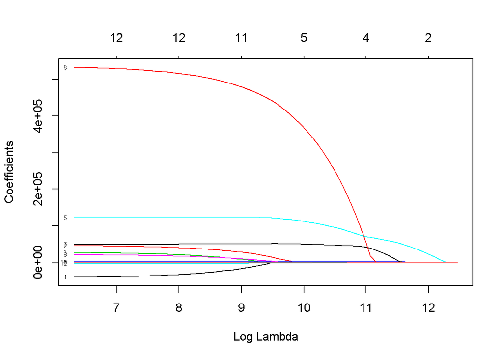

```r
modelos_lasso <- glmnet(x = x, y = y, alpha = 1)
plot(modelos_lasso, xvar = "lambda", label = TRUE)
```

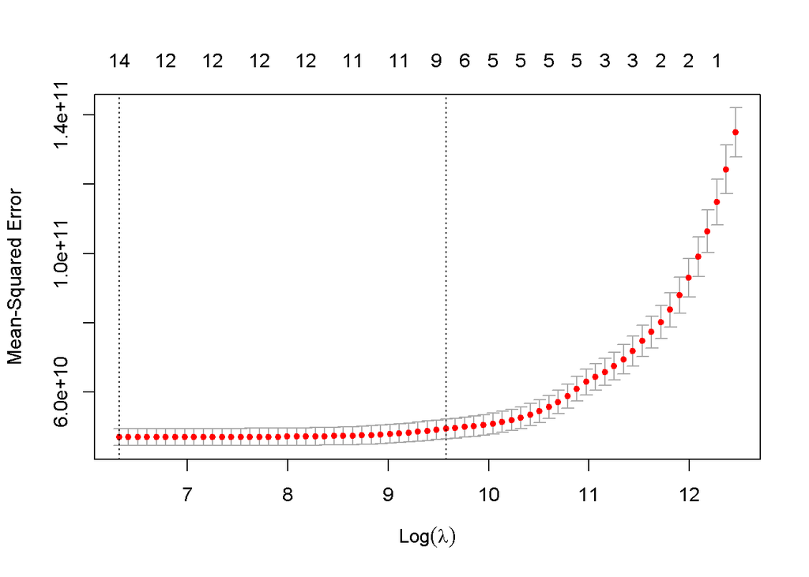

```r
set.seed(737)
cv_error_lasso <- cv.glmnet(x = x, y = y, alpha = 1, nfolds = 10)
plot(cv_error_lasso)
```

Podemos observar cómo varía el error cuadrático medio, en función del valor de regularización. Gráficamente se comprueba que el error no aumenta hasta que las variables con coeficiente mayor que cero es menor que 7.

```r
cv_error_lasso$lambda.min
```

```
## [1] 555.5782
```

```r
cv_error_lasso$lambda.1se
```

```
## [1] 14417.39
```

```r
# Se reajusta el modelo con todas las observaciones empleando el valor de
# lambda óptimo

modelo_final_lasso <- glmnet(x = x, y = y, alpha = 1, lambda = cv_error_lasso$lambda.1se)
coef(modelo_final_lasso)
```

```
## 16 x 1 sparse Matrix of class "dgCMatrix"
##                         s0
## (Intercept)   4214595.2936
## bedrooms            .
## bathrooms        9935.6736
## floors              .
## sqft_living       151.6113
## grade          119970.0883
## condition         920.7866
## view            50409.5432
## waterfront     432030.4296
## sqft_lot            .
## sqft_above          .
## sqft_basement       .
## yr_built        -2510.2088
## yr_renovated        .
## sqft_living15       .
## sqft_lot15          .
```

```r
first_seven <- max(which(cv_error_lasso$nzero == 7))
my_lam <- cv_error_lasso$lambda[first_seven]
out_seven <- glmnet(x,y,alpha=1,lambda = my_lam)
lasso_coef_seven <- predict(out_seven,type="coefficients")
lasso_coef_seven
```

```
## 16 x 1 sparse Matrix of class "dgCMatrix"
##                         s0
## (Intercept)   4214595.2936
## bedrooms            .
## bathrooms        9935.6736
## floors              .
## sqft_living       151.6113
## grade          119970.0883
## condition         920.7866
## view            50409.5432
## waterfront     432030.4296
## sqft_lot            .
## sqft_above          .
## sqft_basement       .
## yr_built        -2510.2088
## yr_renovated        .
## sqft_living15       .
## sqft_lot15          .
```

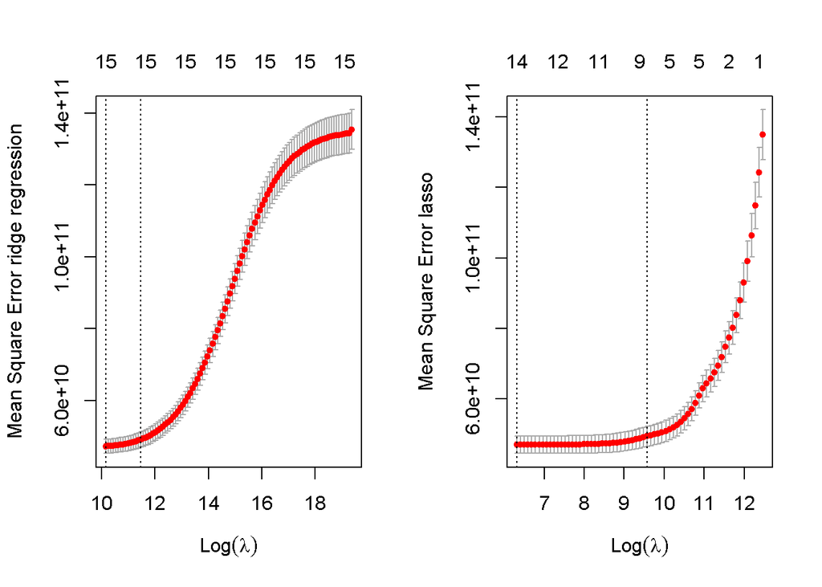

```r
par(mfrow = c(1,2))
plot(cv_error_ridge,ylab = "Mean Square Error ridge regression" )
abline(h = 120000)
plot(cv_error_lasso,ylab = "Mean Square Error lasso")
abline(h = 120000)
```

```r
par(mfrow = c(1,1))
```

# GAM

## How Regression Splines Work

Cubic B-spline requiere 2(q+1)+m . Los inners Knots son lo puntos de estimación necesarios para calcular una smooth función, es decir como una guía de la función smooth¿?, y de qué depende¿? de la variable x¿? The boundary knots son arbitrarios ( esto es aleatorio) y se sitúan en los extremos de los inner knots.¿? Entiendo que son los nudo por donde pasa la Spline a mayor número Overfitting a menor mala estimación.

RSS= Suma (yi-g(xi))2 —> Overfit data , makes RSS small but that also smooth How g is smooth, function

Sum (yi-g(xi))2 +lambda *integral ( g’’(t)2 dt) donde Lambda is not-negative

## Configuración espacial continua

Incluímos la variable Latitud y longitud como una conjunta.

```r
## gam regression
## listado de variables seleccionadas a partior del Lasso

model_gam <- gam (price~ s(lat,long) +s(sqft_living)  +s(sqft_living15) + s(bathrooms)  + s(grade,k=3)   +(waterfront) +   s(view,k=3) + s(yr_built) , data=train, method="REML")



summary(model_gam)
```

```
##
## Family: gaussian
## Link function: identity
##
## Formula:
## price ~ s(lat, long) + s(sqft_living) + s(sqft_living15) + s(bathrooms) +
##     s(grade, k = 3) + (waterfront) + s(view, k = 3) + s(yr_built)
##
## Parametric coefficients:
##             Estimate Std. Error t value Pr(>|t|)
## (Intercept)   535180       1224  437.21   <2e-16 ***
## waterfront    555792      17051   32.59   <2e-16 ***
## ---
## Signif. codes:  0 '***' 0.001 '**' 0.01 '*' 0.05 '.' 0.1 ' ' 1
##
## Approximate significance of smooth terms:
##                     edf Ref.df      F p-value
## s(lat,long)      28.861 28.999 387.76  <2e-16 ***
## s(sqft_living)    8.948  8.998 356.57  <2e-16 ***
## s(sqft_living15)  6.533  7.648  19.50  <2e-16 ***
## s(bathrooms)      8.909  8.995  26.37  <2e-16 ***
## s(grade)          1.999  2.000 939.13  <2e-16 ***
## s(view)           1.984  2.000 311.80  <2e-16 ***
## s(yr_built)       7.929  8.692  33.55  <2e-16 ***
## ---
## Signif. codes:  0 '***' 0.001 '**' 0.01 '*' 0.05 '.' 0.1 ' ' 1
##
## R-sq.(adj) =  0.835   Deviance explained = 83.5%
## -REML = 2.017e+05  Scale est. = 2.2396e+10  n = 15120
```

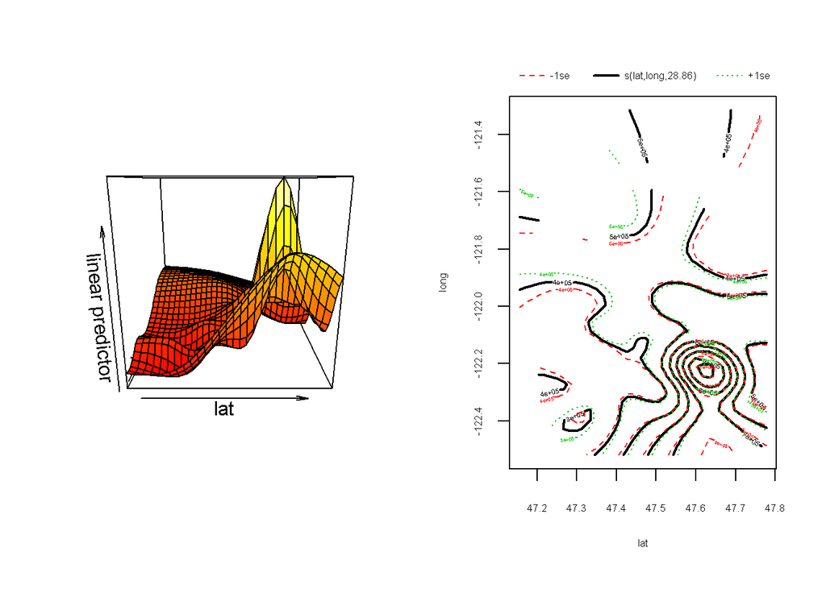

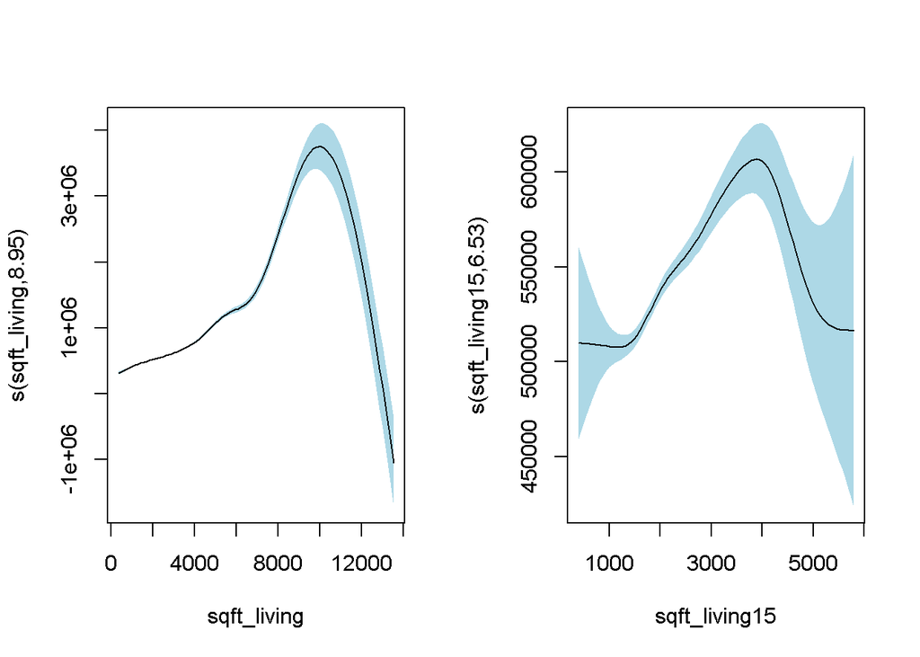

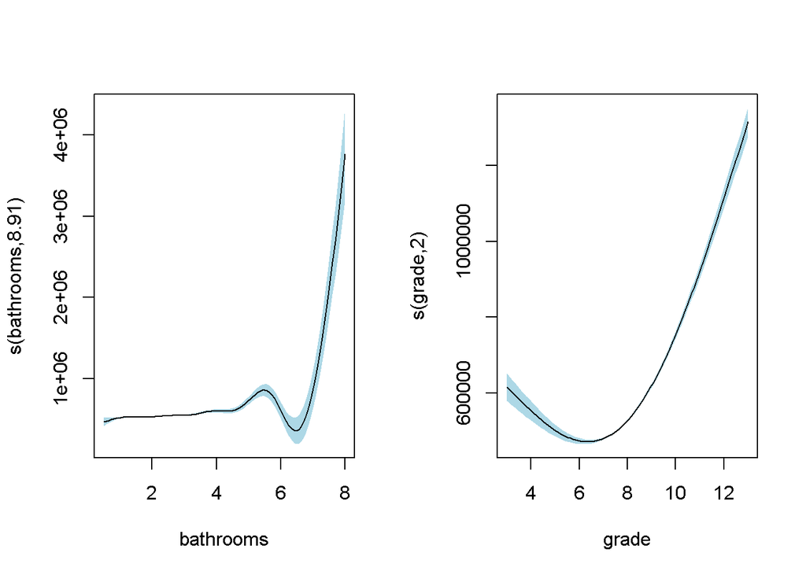

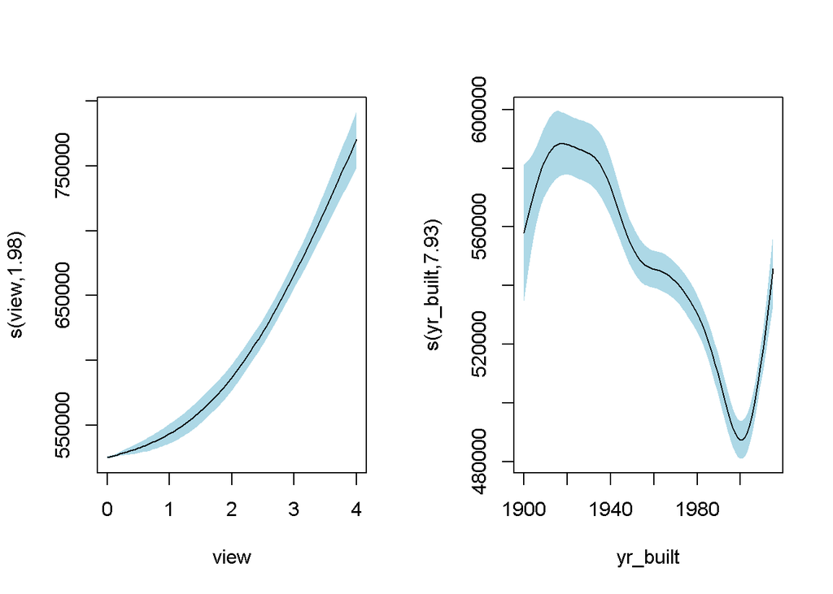

```r
layout(matrix(1:2, ncol = 2))
vis.gam (x=model_gam,view=c("lat","long"),plot.type="persp")
plot(model_gam, scale = 0,shade = TRUE, shade.col = "lightblue" , shift=coef(model_gam)[1])
```

## checking concurvity

La concurrencia ocurre cuando algún término suave en un modelo puede ser aproximado por uno o más de los otros términos suaves en el modelo. Este es a menudo el caso cuando se incluye una suavidad de espacio en un modelo, junto con suavidades de otros covariables que también varían más o menos suavemente en el espacio. Del mismo modo tiende ser un problema en modelos que incluyen un tiempo suave, junto con problemas de otro tiempo variando covariables.

Es esencialmente la forma no lineal de colinealidad, la library mgcv proporciona una medida de concurrencia y establece en la documentación si tales medidas están por encima de> 1.0 es preocupante. La literatura nos dice que se puede esperar concurvity con datos espaciales como es nuestro caso.

La concurrencia puede verse como una generalización de la co-linealidad y sus causas.

índices Relacionados Concurvity, todos entre [0,1]: 1.-Worst 2.-Observed 3.-Estimate

```r
# Check pairwise concurvity
k<-concurvity(model_gam,full=FALSE)

#options(scipen=999)
k$worst
```

```
##                          para  s(lat,long) s(sqft_living) s(sqft_living15)
## para             1.000000e+00 2.156353e-28   3.444284e-22     2.649259e-22
## s(lat,long)      2.703456e-28 1.000000e+00   1.771651e-01     2.926731e-01
## s(sqft_living)   3.443449e-22 1.771651e-01   1.000000e+00     5.946618e-01
## s(sqft_living15) 2.650379e-22 2.926731e-01   5.946618e-01     1.000000e+00
## s(bathrooms)     1.961995e-22 1.484520e-01   8.997085e-01     3.400871e-01
## s(grade)         1.925424e-28 2.102790e-01   6.157629e-01     5.451687e-01
## s(view)          1.139680e-29 7.753406e-02   9.448171e-02     8.447884e-02
## s(yr_built)      3.696218e-22 4.108118e-01   1.687949e-01     1.458553e-01
##                  s(bathrooms)     s(grade)      s(view)  s(yr_built)
## para             1.958344e-22 1.962337e-28 1.082586e-29 3.695965e-22
## s(lat,long)      1.484520e-01 2.102790e-01 7.753406e-02 4.108118e-01
## s(sqft_living)   8.997085e-01 6.157629e-01 9.448171e-02 1.687949e-01
## s(sqft_living15) 3.400871e-01 5.451687e-01 8.447884e-02 1.458553e-01
## s(bathrooms)     1.000000e+00 4.518139e-01 5.152904e-02 3.929230e-01
## s(grade)         4.518139e-01 1.000000e+00 7.945222e-02 2.751641e-01
## s(view)          5.152904e-02 7.945222e-02 1.000000e+00 6.257331e-03
## s(yr_built)      3.929230e-01 2.751641e-01 6.257331e-03 1.000000e+00
```

### GAM CHECK Resids vs linear pred

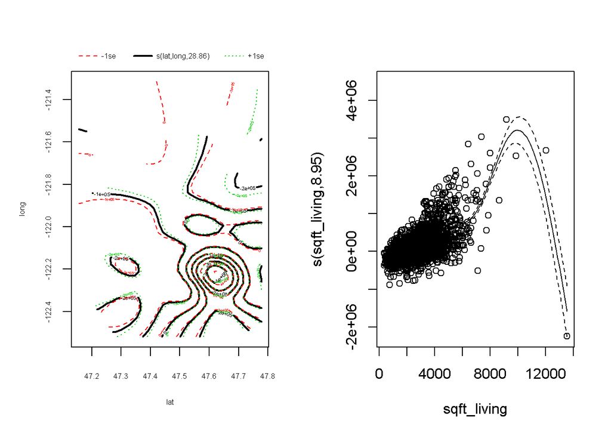

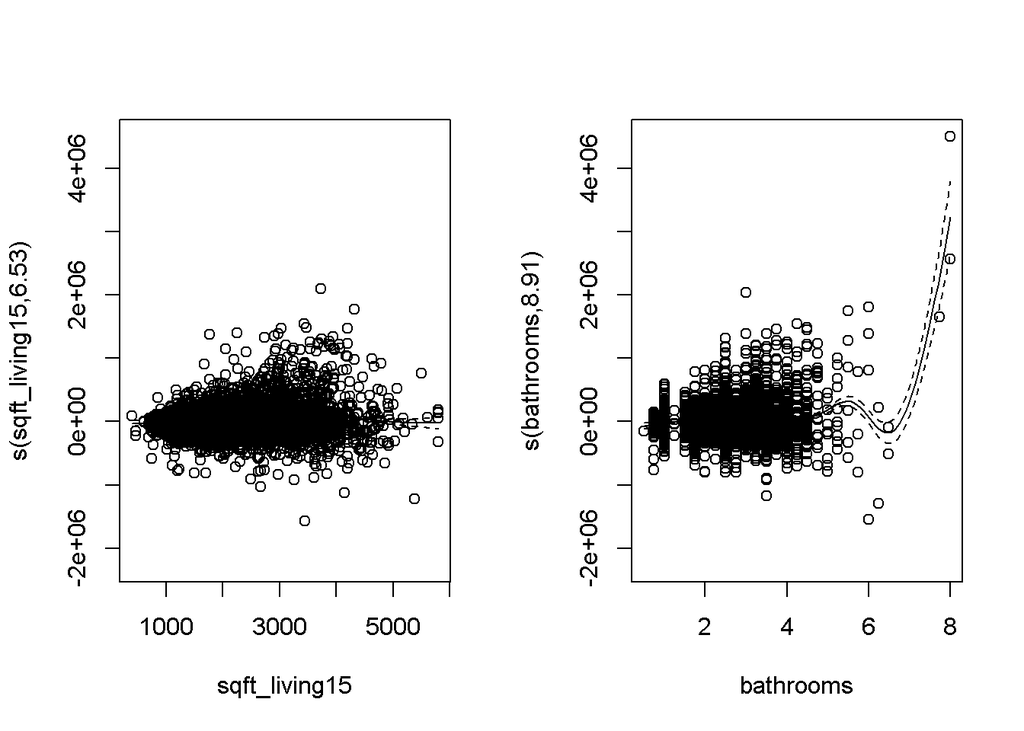

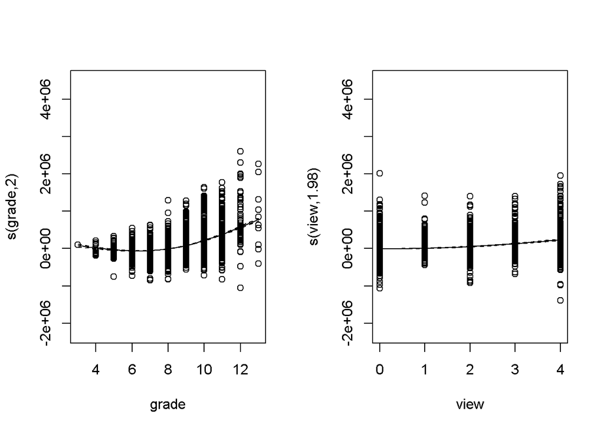

```r
par(mfrow = c(1, 2))
plot(model_gam, residuals = TRUE, pch = 1)
```

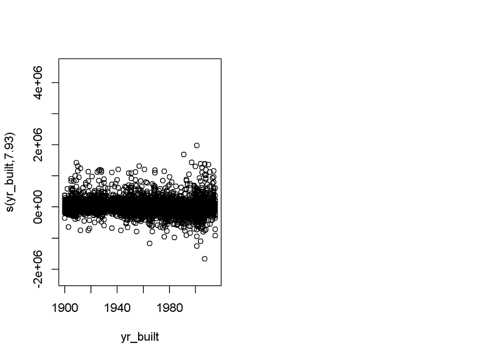

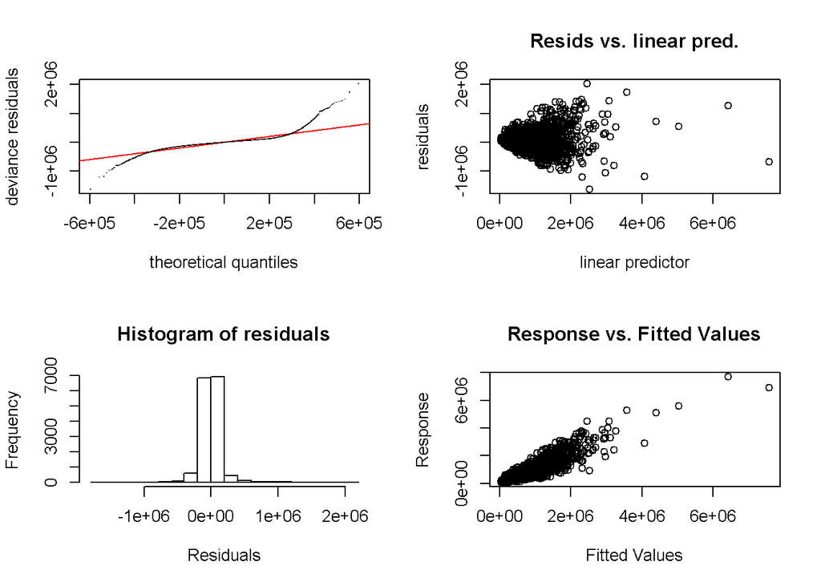

```
##
## Method: REML   Optimizer: outer newton
## full convergence after 9 iterations.
## Gradient range [-0.06559979,0.04165724]
## (score 201696.2 & scale 22396129571).
## Hessian positive definite, eigenvalue range [0.4836751,7555.096].
## Model rank =  71 / 71
##
## Basis dimension (k) checking results. Low p-value (k-index<1) may
## indicate that k is too low, especially if edf is close to k'.
##
##                     k'   edf k-index p-value
## s(lat,long)      29.00 28.86    0.68  <2e-16 ***
## s(sqft_living)    9.00  8.95    0.96  <2e-16 ***
## s(sqft_living15)  9.00  6.53    1.08    1.00
## s(bathrooms)      9.00  8.91    1.01    0.86
## s(grade)          2.00  2.00    0.91  <2e-16 ***
## s(view)           2.00  1.98    1.01    0.76
## s(yr_built)       9.00  7.93    1.01    0.70
## ---
## Signif. codes:  0 '***' 0.001 '**' 0.01 '*' 0.05 '.' 0.1 ' ' 1
```

```r
gam.check(model_gam)
```

Podemos ver ahora (gráfico de Resids vs linear pred) que se incumple la hipótesis de varianza constante ya que la variabilidad de los residuos aumenta cuando lo hace el predictor lineal. Este tipo de problemas se suele arraglar con la tranasformación raíz cuadrada. Aplicamos dicha transformación y ajustamos el nuevo modelo

### Relanzamos el modelo GAM TRASFORMACION CUADRÁTICA Versión 2

```r
# Modelo

model_gam2 <- gam (sqrt(price)~ s(lat,long) +s(sqft_living)  +s(sqft_living15) + s(bathrooms)  + s(grade,k=3)   +(waterfront) +   s(view,k=3) + s(yr_built) , data=train, method="REML")



summary(model_gam2)
```

```
##
## Family: gaussian
## Link function: identity
##
## Formula:
## sqrt(price) ~ s(lat, long) + s(sqft_living) + s(sqft_living15) +
##     s(bathrooms) + s(grade, k = 3) + (waterfront) + s(view, k = 3) +
##     s(yr_built)
##
## Parametric coefficients:
##             Estimate Std. Error t value Pr(>|t|)
## (Intercept) 704.0677     0.5941 1185.17   <2e-16 ***
## waterfront  236.0209     8.2556   28.59   <2e-16 ***
## ---
## Signif. codes:  0 '***' 0.001 '**' 0.01 '*' 0.05 '.' 0.1 ' ' 1
##
## Approximate significance of smooth terms:
##                     edf Ref.df       F  p-value
## s(lat,long)      28.883 28.999  691.72  < 2e-16 ***
## s(sqft_living)    8.845  8.989  338.65  < 2e-16 ***
## s(sqft_living15)  4.591  5.708   57.51  < 2e-16 ***
## s(bathrooms)      2.659  3.384   21.52 8.12e-15 ***
## s(grade)          1.997  2.000 1028.76  < 2e-16 ***
## s(view)           1.967  1.999  366.21  < 2e-16 ***
## s(yr_built)       8.147  8.798   50.71  < 2e-16 ***
## ---
## Signif. codes:  0 '***' 0.001 '**' 0.01 '*' 0.05 '.' 0.1 ' ' 1
##
## R-sq.(adj) =  0.872   Deviance explained = 87.2%
## -REML =  86365  Scale est. = 5275.4    n = 15120
```

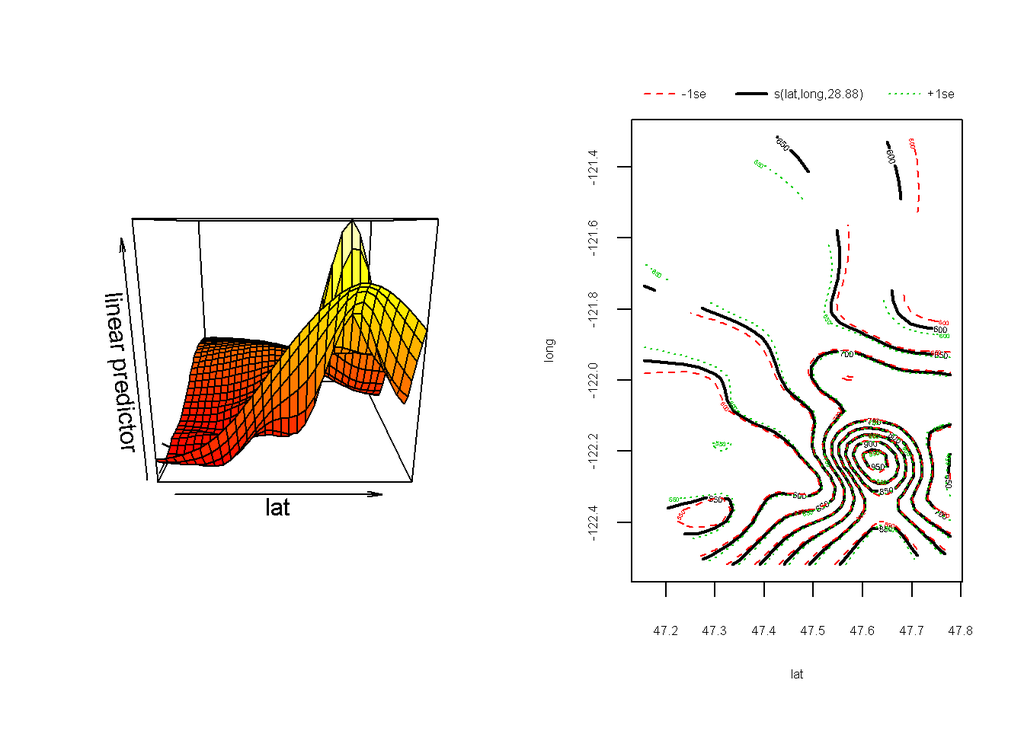

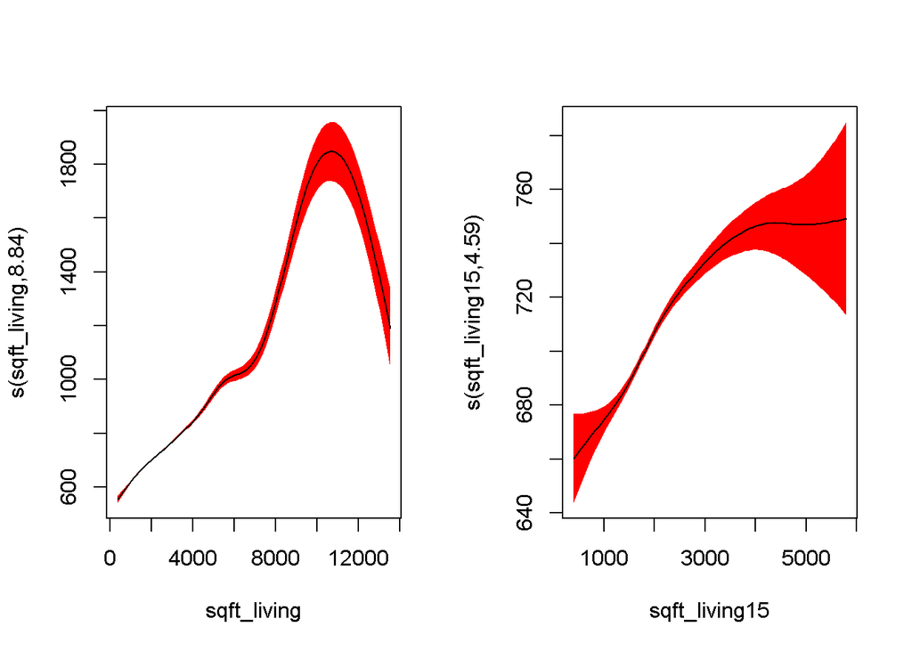

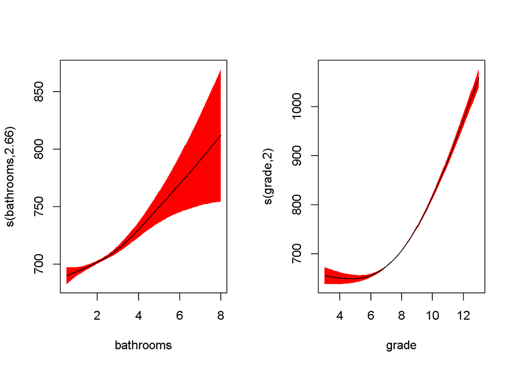

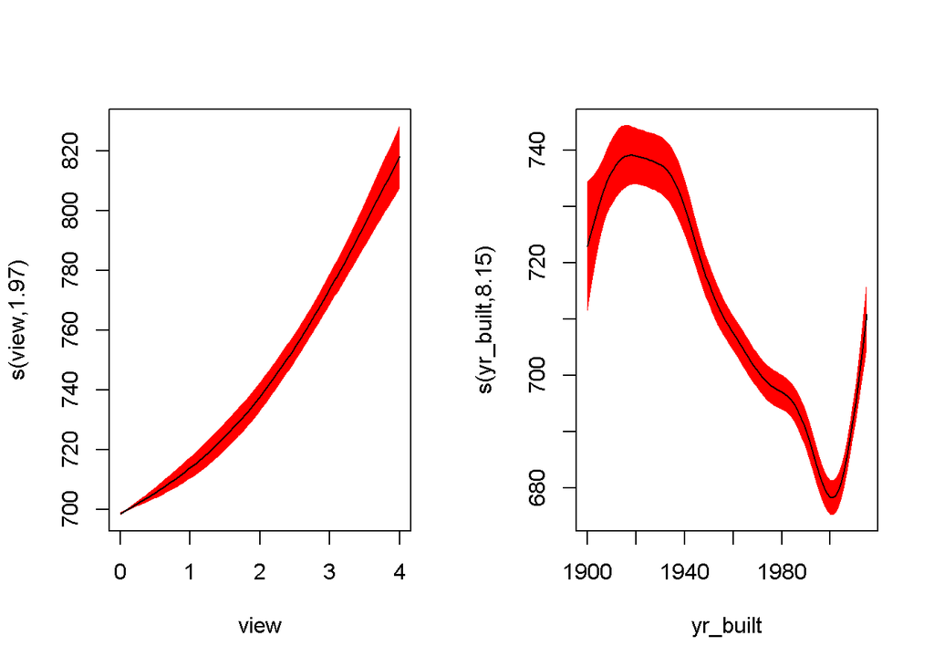

```r
layout(matrix(1:2, ncol = 2))
vis.gam (x=model_gam2,view=c("lat","long"),plot.type="persp")
plot(model_gam2, scale = 0,shade = TRUE, shade.col = "red" , shift=coef(model_gam2)[1])
```

## GAM FIT

Verificar un GAM fitted es como verificar un GLM fitted pero con dos diferencias fundamentales: 1.-Las dimensiones básicas utilizadas para los términos suaves deben verificarse 2.-En segundo lugar, supuestos de distribución GLM regular, los GAM pueden ser más sensibles. Por ello se usa un gráfico QQ residual mejorado.

Esta función representa 4 gráficos de diagnóstico estándar

1.-The test of whether the basis dimension for a smooth is adequate. Ver si el nivel de Smooth es el adecuado. Los valores p bajos pueden indicar que la dimensión base, k, se ha establecido demasiado baja, especialmente si el EDF informado está cerca de k ‘, el FED máximo posible para el término. Duplicar a un ’k’ sospechoso y volver a ajustarlo es una buena prueba 2.-QQ Gam 3.-Distribución de la varianza de los errores 4.-Response vs Fitted Value.

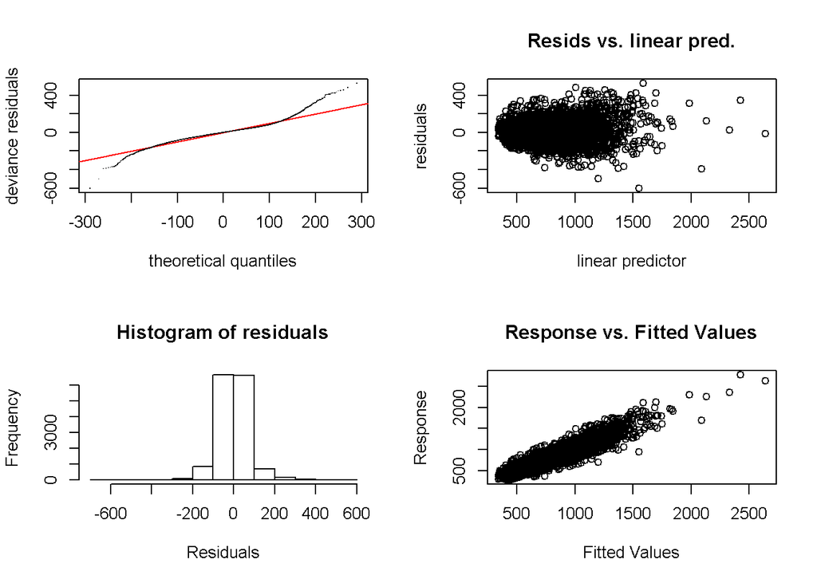

```
##
## Method: REML   Optimizer: outer newton
## full convergence after 11 iterations.
## Gradient range [-0.009026913,0.008811526]
## (score 86364.65 & scale 5275.421).
## Hessian positive definite, eigenvalue range [0.4679674,7555.037].
## Model rank =  71 / 71
##
## Basis dimension (k) checking results. Low p-value (k-index<1) may
## indicate that k is too low, especially if edf is close to k'.
##
##                     k'   edf k-index p-value
## s(lat,long)      29.00 28.88    0.75  <2e-16 ***
## s(sqft_living)    9.00  8.84    1.00    0.57
## s(sqft_living15)  9.00  4.59    0.99    0.37
## s(bathrooms)      9.00  2.66    0.97    0.02 *
## s(grade)          2.00  2.00    1.01    0.80
## s(view)           2.00  1.97    1.00    0.54
## s(yr_built)       9.00  8.15    1.00    0.57
## ---
## Signif. codes:  0 '***' 0.001 '**' 0.01 '*' 0.05 '.' 0.1 ' ' 1
```

```r
# Diagnóstico
gam.check(model_gam2)
```

### Relanzamos el modelo GAM Modificando los K Versión 3

```r
# Diagnóstico


model_gam3 <- gam (sqrt(price)~ s(lat,long,k=20) +s(sqft_living,k=8)  +s(sqft_living15) + s(bathrooms,k=8)  + s(grade,k=3)   +(waterfront) +   s(view,k=3) + s(yr_built) , data=train, method="REML")

summary(model_gam3)
```

```
##
## Family: gaussian
## Link function: identity
##
## Formula:
## sqrt(price) ~ s(lat, long, k = 20) + s(sqft_living, k = 8) +
##     s(sqft_living15) + s(bathrooms, k = 8) + s(grade, k = 3) +
##     (waterfront) + s(view, k = 3) + s(yr_built)
##
## Parametric coefficients:
##             Estimate Std. Error t value Pr(>|t|)
## (Intercept) 704.0001     0.6346 1109.33   <2e-16 ***
## waterfront  244.8312     8.7227   28.07   <2e-16 ***
## ---
## Signif. codes:  0 '***' 0.001 '**' 0.01 '*' 0.05 '.' 0.1 ' ' 1
##
## Approximate significance of smooth terms:
##                     edf Ref.df       F p-value
## s(lat,long)      18.936 19.000  827.88  <2e-16 ***
## s(sqft_living)    6.886  6.991  368.50  <2e-16 ***
## s(sqft_living15)  5.283  6.441   70.79  <2e-16 ***
## s(bathrooms)      3.196  3.937   21.34  <2e-16 ***
## s(grade)          1.997  2.000 1089.57  <2e-16 ***
## s(view)           1.950  1.998  284.48  <2e-16 ***
## s(yr_built)       8.128  8.789   59.47  <2e-16 ***
## ---
## Signif. codes:  0 '***' 0.001 '**' 0.01 '*' 0.05 '.' 0.1 ' ' 1
##
## R-sq.(adj) =  0.854   Deviance explained = 85.4%
## -REML =  87329  Scale est. = 6021.7    n = 15120
```

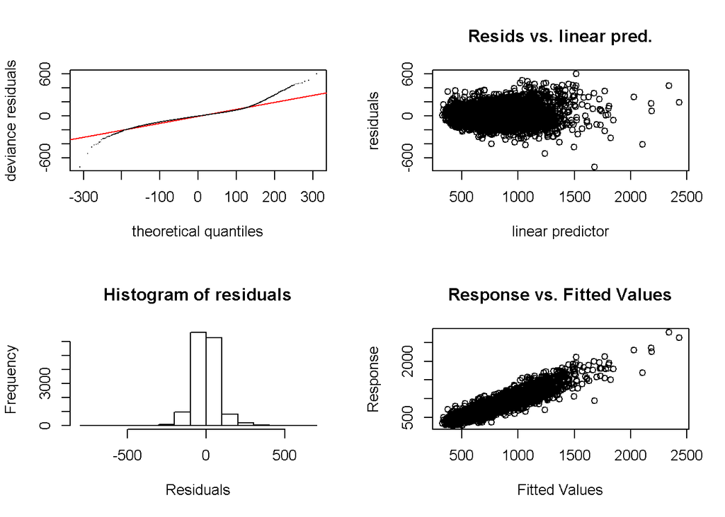

```
##
## Method: REML   Optimizer: outer newton
## full convergence after 12 iterations.
## Gradient range [-0.006321214,0.006238381]
## (score 87329.19 & scale 6021.664).
## Hessian positive definite, eigenvalue range [0.4516299,7555.019].
## Model rank =  57 / 57
##
## Basis dimension (k) checking results. Low p-value (k-index<1) may
## indicate that k is too low, especially if edf is close to k'.
##
##                     k'   edf k-index p-value
## s(lat,long)      19.00 18.94    0.68  <2e-16 ***
## s(sqft_living)    7.00  6.89    0.99    0.15
## s(sqft_living15)  9.00  5.28    0.97    0.02 *
## s(bathrooms)      7.00  3.20    0.99    0.22
## s(grade)          2.00  2.00    1.00    0.36
## s(view)           2.00  1.95    0.99    0.37
## s(yr_built)       9.00  8.13    0.97    0.03 *
## ---
## Signif. codes:  0 '***' 0.001 '**' 0.01 '*' 0.05 '.' 0.1 ' ' 1
```

```r
# Diagnóstico
gam.check(model_gam3)
```

### Comparamos RME Poblacion Control modelo GAM1 modelo GAM3

```r
pred.modelo.gam1 <-  predict(model_gam, control)
new1=sqrt(control$price)
test.error.gam1 <- mean((pred.modelo.gam1 - new1)^2)

pred.modelo.gam2 <-  predict(model_gam2, control)
new2=sqrt(control$price)
test.error.gam2 <- mean((pred.modelo.gam2 - new2)^2)

pred.modelo.gam3 <-  predict(model_gam3, control)
new3=sqrt(control$price)
test.error.gam3 <- mean((pred.modelo.gam3 - new3)^2)
```

### Representación Gráfica de estos RME

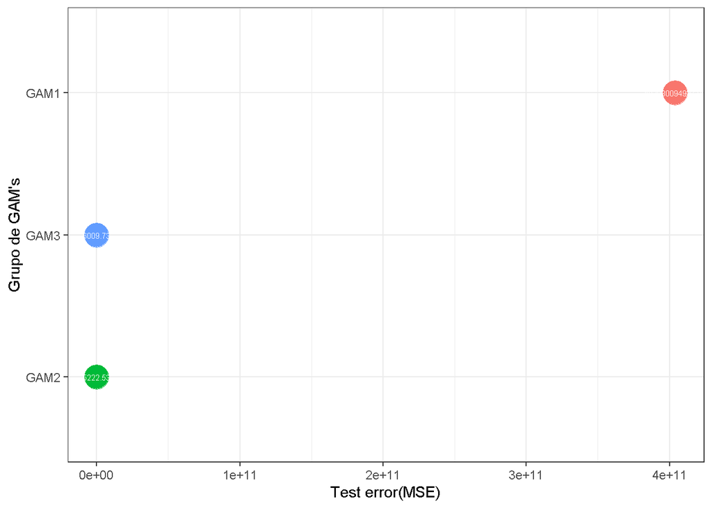

```r
modelo <- c("GAM1", "GAM2",  "GAM3")
test.MSE <- c(test.error.gam1,test.error.gam2,test.error.gam3)

comparacion <- data.frame(modelo = modelo, test.MSE = test.MSE)

ggplot(data = comparacion, aes(x = reorder(x = modelo, X = test.MSE),
                               y = test.MSE, color = modelo,
                               label = round(test.MSE,2))) +
geom_point(size = 8) +
geom_text(color = "white", size = 2) +
labs(x = "Grupo de GAM's", y = "Test error(MSE)") + theme_bw() +
coord_flip() + theme(legend.position = "none")
```

### cáculo del R2 Modelo 3 para la poblacion Validation

```r
SST <- mean((new3 - mean(new2))^2)
SSE <- test.error.gam3
R2 <- 1 - SSE / SST
R2
```

```
## [1] 0.8549512
```

[output not shown]